# Exploratory Data Analysis

STOR 320.01 Group 14

March 29, 2026

## Data Dictionary

```r
data_dictonary <- tribble(
  ~Variable, ~Type, ~Meaning,
  "name", "Character", "Name of deceased",
  "age", "Numeric", "Age of deceased",
  "gender", "Cateogical", "Gender of deceased",
  "raceethnicity", "Categorical", "Race/ethnicity of deceased",
  "month", "Numeric", "Month of killing",
  "day", "Numeric", "Day of incident",
  "year", "Numeric", "Year of incident",
  "streetaddress", "character", "Address/intersection where incident occurred",
  "city", "character", "City where incident occurred",
  "state", "character", "State where incident occurred",
  "latitude", "Numeric", "Latitude, geocoded from address",
  "longitude", "Numeric", "Longitude, geocoded from address",
  "state_fp", "Numeric", "State FIPS code",
  "county_fp", "Numeric", "County FIPS code",
  "tract_ce", "Numeric", "Tract ID code",
  "geo_id", "Numeric", "Combined tract ID code",
  "county_id", "Numeric", "Combined county ID code",
  "namelsad", "Character", "Tract description",
  "lawenforcementagency", "Character", "Agency involved in incident",
  "cause", "Cateogical", "Cause of death",
  "armed", "Cateogical", "How/whether deceased was armed",
  "pop", "Numeric", "Tract population",
  "share_white", "Numeric", "Share of pop that is non-Hispanic white",
  "share_black", "Numeric", "Share of pop that is black (alone, not in combination)",
  "share_hispanic", "Numeric", "Share of pop that is Hispanic/Latino (any race)",
  "p_income", "Numeric", "Tract-level median personal income",
  "h_income", "Numeric", "Tract-level median household income",
  "county_income", "Numeric", "County-level median household income",
  "comp_income", "Numeric", "h_income / county_income",
  "county_bucket", "Numeric", "Household income, quintile within county",
  "nat_bucket", "Numeric", "Household income, quintile nationally",
  "pov", "Numeric", "Tract-level poverty rate (official)",
  "urate", "Numeric", "Tract-level unemployment rate",
  "college", "Numeric", "Share of 25+ pop with BA or higher",
)
data_dictonary |> gt()
```

| Variable | Type | Meaning |
| --- | --- | --- |
| name | Character | Name of deceased |
| age | Numeric | Age of deceased |
| gender | Cateogical | Gender of deceased |
| raceethnicity | Categorical | Race/ethnicity of deceased |
| month | Numeric | Month of killing |
| day | Numeric | Day of incident |
| year | Numeric | Year of incident |
| streetaddress | character | Address/intersection where incident occurred |
| city | character | City where incident occurred |
| state | character | State where incident occurred |
| latitude | Numeric | Latitude, geocoded from address |
| longitude | Numeric | Longitude, geocoded from address |
| state_fp | Numeric | State FIPS code |
| county_fp | Numeric | County FIPS code |
| tract_ce | Numeric | Tract ID code |
| geo_id | Numeric | Combined tract ID code |
| county_id | Numeric | Combined county ID code |
| namelsad | Character | Tract description |
| lawenforcementagency | Character | Agency involved in incident |
| cause | Cateogical | Cause of death |
| armed | Cateogical | How/whether deceased was armed |
| pop | Numeric | Tract population |
| share_white | Numeric | Share of pop that is non-Hispanic white |
| share_black | Numeric | Share of pop that is black (alone, not in combination) |
| share_hispanic | Numeric | Share of pop that is Hispanic/Latino (any race) |
| p_income | Numeric | Tract-level median personal income |
| h_income | Numeric | Tract-level median household income |
| county_income | Numeric | County-level median household income |
| comp_income | Numeric | h_income / county_income |
| county_bucket | Numeric | Household income, quintile within county |
| nat_bucket | Numeric | Household income, quintile nationally |
| pov | Numeric | Tract-level poverty rate (official) |
| urate | Numeric | Tract-level unemployment rate |
| college | Numeric | Share of 25+ pop with BA or higher |

## Statement of the Business Problem:

Police use of lethal force is a critical public safety and civil rights concern in the United States. This dataset, compiled by FiveThirtyEight(https://github.com/fivethirtyeight/data/tree/master/police-killings), records 467 people killed by police during the first half of 2015 and links each incident to census-tract-level socioeconomic indicators such as household income, poverty rate, unemployment, and races of victims. Our exploratory analysis explores the relationship between economic indicators and incident frequency. We investigates whether how specific law enforcement agencies operate in low-income areas, explores how victim demographics such as age and race intersect with neighborhood poverty, and examine the relationships between socioeconomic factors like unemployment, low education, and low income. Together, these analyses aim to identify which conditions are most strongly connected with police killings and whether those patterns hold across racial groups and geographic locations.

```r
data_issue_tribble <- tribble(
  ~Variable, ~Issue, ~Strategy,
  "Armed", "Many values for yes", "Mutate into Yes/No",
  "Cause", "Many categories for death", "Mutate into Gunshot/Other",
  "Many (including raceethnicity, month, age etc.", "Not correct variable type", "Mutate to correct variable type"
)
data_issue_tribble |> gt()
```

| Variable | Issue | Strategy |
| --- | --- | --- |
| Armed | Many values for yes | Mutate into Yes/No |
| Cause | Many categories for death | Mutate into Gunshot/Other |
| Many (including raceethnicity, month, age etc. | Not correct variable type | Mutate to correct variable type |

## Data Issues and Outline of proposed Handling Techniques:

```r
df <- df |>
    clean_names() |>
    mutate(across(where(is.character), ~ str_squish(.))) |>
    mutate(across(where(is.character),
                ~ na_if(.x, ""))) |>
    mutate(across(where(is.character),
                ~ case_when(
                  .x %in% c("NA", "N/A", "null", "NULL", "?", "unknown", "Unknown", "-", " - ", " -", "- ") ~ NA_character_,
                  TRUE ~ .x
                )))
df <- df |>
    mutate(across(where(is.numeric),
                ~ case_when(
                  .x %in% c("NA", "N/A", "null", "NULL", "?", "unknown", "Unknown", "-", " - ", " -", "- ") ~ NA_integer_,
                  TRUE ~ .x
                )))
df <- df |>
  mutate(
    age = as.integer(age),
    gender = as.factor(gender),
    raceethnicity = as.factor(raceethnicity),
    month = as.factor(month),
    state = as.factor(state),
    share_white = as.numeric(share_white),
    share_black = as.numeric(share_black),
    comp_income = as.numeric(comp_income),
    share_hispanic = as.numeric(share_hispanic),
    p_income = as.numeric(p_income),
    pov = as.numeric(pov),
    urate = as.numeric(urate),
    college = as.numeric(college)
  )

df <- df |>
    mutate(
        armed = case_when(
            armed %in% c("No") ~ "No",
            TRUE ~ "Yes"
        ))
df <- df |>
    mutate(
        cause = case_when(
            cause %in% c("Gunshot") ~ "Gunshot",
            TRUE ~ "Other"
        ))
df <- df |>
  mutate(cause = as.factor(cause)) |>
  mutate(armed = as.factor(armed))
```

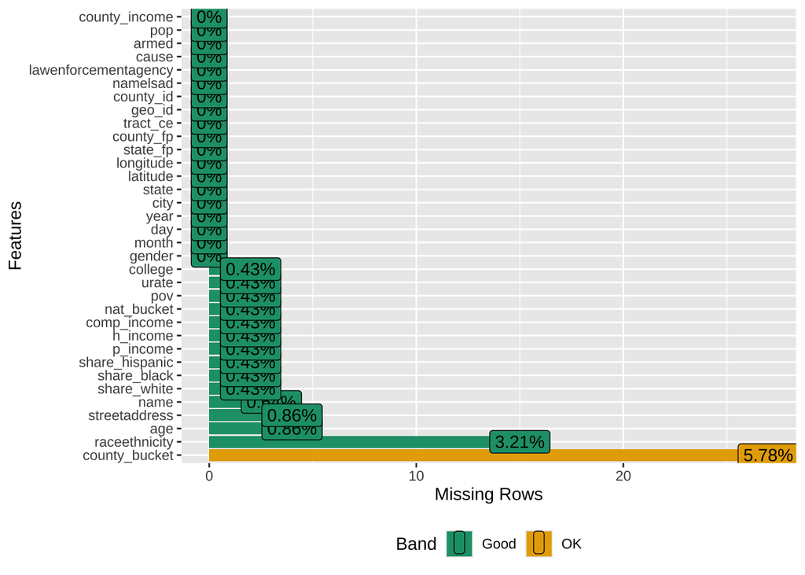

```r
suppressWarnings(DataExplorer::plot_missing(df))
```

## Data Quality Report for Numerical:

The dataset contains 14 numerical or numeric convertible features. “pop” (tract population) has no missing values and ranges from 0 to 26,826 with a mean of 4,784. “h_income” (tract median household income) and comp_income (ratio of tract to county income) each have 2 missing values. “h_income” ranges from $10,290 to $142,500 with a mean of $46,627, while “comp_income” ranges from 0.18 to 2.87 with a mean of 0.90, showing that the average incident occurs in a tract earning about 90% of its county’s median. “county_income” is fully observed, ranging from $22,545 to $110,292. “p_income” (per capita income) is stored as character but converts cleanly for 465 of 467 rows, ranging from $5,457 to $86,023. “pov” (tract poverty rate) is also stored as character and converts for 465 rows, ranging from 1.1% to 79.2% with a mean of 21.1%. “urate” (unemployment rate) and college (share with a college degree) each have 2 missing values, “urate” ranges from 0.01 to 0.51 (mean 0.12), and college ranges from 0.01 to 0.83 (mean 0.22). The demographic is “share_white”, “share_black”, and “share_hispanic”, are all stored as character and each have 2 values that coerce to NA upon numeric conversion. “county_bucket” has 27 missing values, more than the other variables, suggesting that some tracts could not be mapped to county income quintiles. nat_bucket has 2 missing values. age is stored as character because 4 entries contain “Unknown” rather than a number, the remaining 463 values convert cleanly, ranging from 16 to 87.

## Categorical Features:

There are six key categorical columns. “gender” has no missing values, with 445 males (95.3%) and 22 females. “raceethnicity” has 6 unique levels: White (236), Black (135), Hispanic/Latino (67), Unknown (15), Asian/Pacific Islander (10), and Native American (4), the 15 “Unknown” entries bring some limit on race-based analysis slightly. “month” spans January through June, but June has only 2 records, making it a 5 month dataset. “cause” has 5 levels dominated by Gunshot (411 of 467, or 88%), followed by Taser (27), Death in custody (14), Struck by vehicle (12), and Unknown (3). “armed” has 8 levels: Firearm (230), No (102), Knife (68), Other (26), Vehicle (18), Non-lethal firearm (14), Unknown (7), and Disputed (2). “state” covers 47 unique states, led by California (74), Texas (46), and Florida (29).

```r
glimpse(df)
```

```
## Rows: 467
## Columns: 34
## $ name                 <chr> "A'donte Washington", "Aaron Rutledge", "Aaron Si…
## $ age                  <int> 16, 27, 26, 25, 29, 29, 22, 35, 44, 31, 76, 40, N…
## $ gender               <fct> Male, Male, Male, Male, Male, Male, Male, Male, M…
## $ raceethnicity        <fct> Black, White, White, Hispanic/Latino, White, Whit…
## $ month                <fct> February, April, March, March, March, March, Marc…
## $ day                  <int> 23, 2, 14, 11, 19, 7, 27, 26, 28, 7, 26, 12, 20, …
## $ year                 <int> 2015, 2015, 2015, 2015, 2015, 2015, 2015, 2015, 2…
## $ streetaddress        <chr> "Clearview Ln", "300 block Iris Park Dr", "22nd A…
## $ city                 <chr> "Millbrook", "Pineville", "Kenosha", "South Gate"…
## $ state                <fct> AL, LA, WI, CA, OH, AZ, CA, CA, TX, MI, CA, CA, T…
## $ latitude             <dbl> 32.52958, 31.32174, 42.58356, 33.93930, 41.14857,…
## $ longitude            <dbl> -86.36283, -92.43486, -87.83571, -118.21946, -81.…
## $ state_fp             <int> 1, 22, 55, 6, 39, 4, 6, 6, 48, 26, 6, 6, 48, 18, …
```

[output cut: 21 more lines]

```r
str(df)
```

```
## 'data.frame':    467 obs. of  34 variables:
##  $ name                : chr  "A'donte Washington" "Aaron Rutledge" "Aaron Siler" "Aaron Valdez" ...
##  $ age                 : int  16 27 26 25 29 29 22 35 44 31 ...
##  $ gender              : Factor w/ 2 levels "Female","Male": 2 2 2 2 2 2 2 2 2 2 ...
##  $ raceethnicity       : Factor w/ 5 levels "Asian/Pacific Islander",..: 2 5 5 3 5 5 3 3 5 5 ...
##  $ month               : Factor w/ 6 levels "April","February",..: 2 1 5 5 5 5 5 5 3 2 ...
##  $ day                 : int  23 2 14 11 19 7 27 26 28 7 ...
##  $ year                : int  2015 2015 2015 2015 2015 2015 2015 2015 2015 2015 ...
##  $ streetaddress       : chr  "Clearview Ln" "300 block Iris Park Dr" "22nd Ave and 56th St" "3000 Seminole Ave" ...
##  $ city                : chr  "Millbrook" "Pineville" "Kenosha" "South Gate" ...
##  $ state               : Factor w/ 47 levels "AK","AL","AR",..: 2 19 45 5 35 4 5 5 41 23 ...
##  $ latitude            : num  32.5 31.3 42.6 33.9 41.1 ...
##  $ longitude           : num  -86.4 -92.4 -87.8 -118.2 -81.4 ...
##  $ state_fp            : int  1 22 55 6 39 4 6 6 48 26 ...
##  $ county_fp           : int  51 79 59 37 153 13 29 37 41 81 ...
```

[output cut: 20 more lines]

```r
funModeling::data_integrity(df)
```

```
## $vars_num_with_NA
##                      variable q_na        p_na
## age                       age    4 0.008565310
## share_white       share_white    2 0.004282655
## share_black       share_black    2 0.004282655
## share_hispanic share_hispanic    2 0.004282655
## p_income             p_income    2 0.004282655
## h_income             h_income    2 0.004282655
## comp_income       comp_income    2 0.004282655
## county_bucket   county_bucket   27 0.057815846
## nat_bucket         nat_bucket    2 0.004282655
## pov                       pov    2 0.004282655
## urate                   urate    2 0.004282655
## college               college    2 0.004282655
##
## $vars_cat_with_NA
##                    variable q_na        p_na
## raceethnicity raceethnicity   15 0.032119914
## streetaddress streetaddress    4 0.008565310
## name                   name    3 0.006423983
##
## $vars_cat_high_card
##                                  variable unique
## name                                 name    464
## streetaddress               streetaddress    459
## namelsad                         namelsad    389
## lawenforcementagency lawenforcementagency    377
## city                                 city    364
## state                               state     47
##
## $MAX_UNIQUE
## [1] 35
##
## $vars_one_value
## [1] "year"
##
## $vars_cat
##  [1] "name"                 "gender"               "raceethnicity"
##  [4] "month"                "streetaddress"        "city"
##  [7] "state"                "namelsad"             "lawenforcementagency"
## [10] "cause"                "armed"
##
## $vars_num
##  [1] "age"            "day"            "year"           "latitude"
##  [5] "longitude"      "state_fp"       "county_fp"      "tract_ce"
##  [9] "geo_id"         "county_id"      "pop"            "share_white"
## [13] "share_black"    "share_hispanic" "p_income"       "h_income"
## [17] "county_income"  "comp_income"    "county_bucket"  "nat_bucket"
## [21] "pov"            "urate"          "college"
##
## $vars_char
## [1] "name"                 "streetaddress"        "city"
## [4] "namelsad"             "lawenforcementagency"
##
## $vars_factor
## [1] "gender"        "raceethnicity" "month"         "state"
## [5] "cause"         "armed"
##
## $vars_other
## character(0)
```

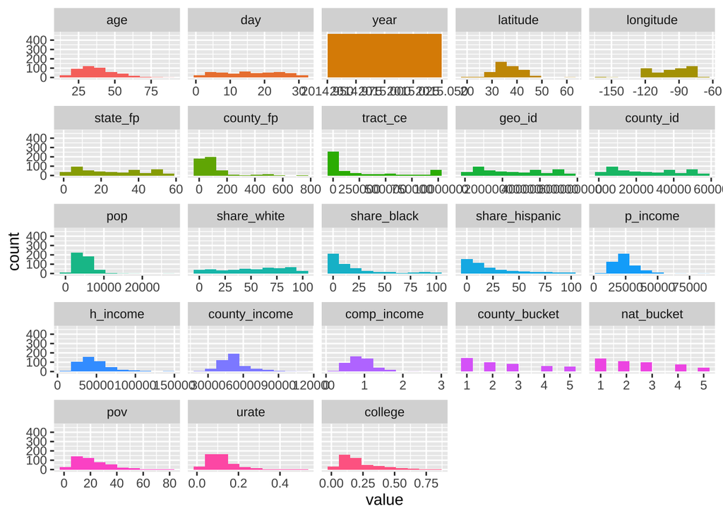

```r
funModeling::plot_num(df)
```

# Creator: Jinlong Li

## Q1: What is the relationship between income, unemployment rate, and education level in tracts where police killings occur?

```r
#What is the relationship between income, unemployment rate, and education level in tracts where police killings occur?

df_q1 <- df %>%
  select(h_income, urate, college) %>%
  drop_na()

summary(df_q1)
```

```
##     h_income          urate            college
##  Min.   : 10290   Min.   :0.01134   Min.   :0.01355
##  1st Qu.: 32625   1st Qu.:0.06859   1st Qu.:0.10617
##  Median : 42759   Median :0.10518   Median :0.16954
##  Mean   : 46627   Mean   :0.11740   Mean   :0.22022
##  3rd Qu.: 56190   3rd Qu.:0.14083   3rd Qu.:0.28454
##  Max.   :142500   Max.   :0.50761   Max.   :0.82807
```

```r
cor(df_q1)
```

```
##            h_income      urate    college
## h_income  1.0000000 -0.5099070  0.6695766
## urate    -0.5099070  1.0000000 -0.4586222
## college   0.6695766 -0.4586222  1.0000000
```

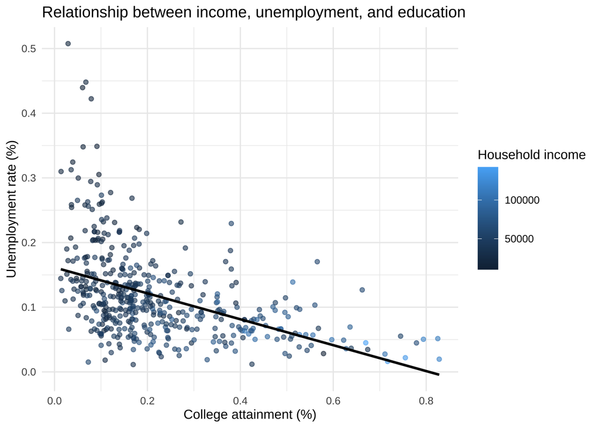

```r
ggplot(df_q1, aes(x = college, y = urate, color = h_income)) +
  geom_point(alpha = 0.6) +
  geom_smooth(method = "lm", se = FALSE, color = "black") +
  labs(
    title = "Relationship between income, unemployment, and education",
    x = "College attainment (%)",
    y = "Unemployment rate (%)",
    color = "Household income"
  ) +
  theme_minimal()
```

### Q2: Is there an association between victim race and the dominant racial group in the tract where the police killing occurred?

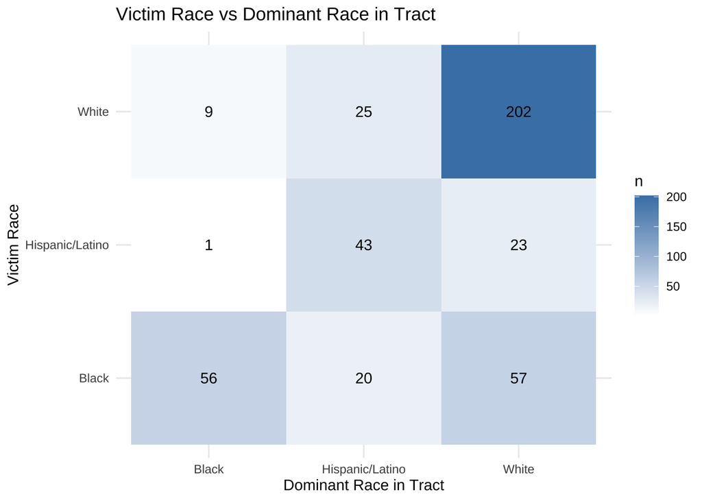

```r
#Is there an association between victim race and the dominant racial group in the tract where the police killing occurred?

df_q2 <- df %>%
  filter(raceethnicity %in% c("White", "Black", "Hispanic/Latino")) %>%
  mutate(
    dominant_race = case_when(
      share_white >= share_black & share_white >= share_hispanic ~ "White",
      share_black >= share_white & share_black >= share_hispanic ~ "Black",
      share_hispanic >= share_white & share_hispanic >= share_black ~ "Hispanic/Latino",
      TRUE ~ NA_character_
    )
  )

heatmap_data <- df_q2 %>%
  filter(!is.na(dominant_race)) %>%
  count(raceethnicity, dominant_race)

ggplot(heatmap_data, aes(x = dominant_race, y = raceethnicity, fill = n)) +
  geom_tile() +
  geom_text(aes(label = n)) +
  scale_fill_gradient(low = "white", high = "steelblue") +
  labs(
    title = "Victim Race vs Dominant Race in Tract",
    x = "Dominant Race in Tract",
    y = "Victim Race"
  ) +
  theme_minimal()
```

A strong diagonal pattern is observed, indicating that victims are often from the same racial group as the dominant population in their area. The heatmap shows a clear association between victim race and the dominant racial group of the tract. This pattern is most pronounced for White victims, who are overwhelmingly found in White-dominant tracts (202 cases). Hispanic/Latino victims also show a strong concentration in Hispanic-dominant areas (43 cases), though a noticeable portion appears in White-dominant tracts (23 cases). In contrast, Black victims display a more dispersed pattern, appearing in both Black-dominant (56 cases) and White-dominant tracts (57 cases). Overall, while there is evidence of same-race concentration, the strength of this pattern differs across racial groups, with White victims showing the strongest alignment and Black victims showing the weakest.

# Interpreter: Enci Zhang

### Q1: Does the classification of death by police show a seasonal trend or vary significantly by the month of the year?

The data covers January through early June 2015, with only 2 entries in June. Within this window, March has the highest count at 114 incidents, followed by April (96), January (90), February (84), and May (81). Gunshot is overwhelmingly the dominant cause of death across all months, accounting for about 88% of all incidents. Taser-related deaths show a slight increase in March and April (8 each) compared to earlier months, and deaths in custody remain rare. Overall, the monthly totals fluctuate slightly, but no clear seasonal trend exists for any cause of death within this five-month window.

```r
pk_raw <- read.csv("police_killings.csv")
pk_raw$month <- factor(pk_raw$month, levels = c("January","February","March","April","May","June"), ordered = TRUE)

q1_table <- pk_raw %>%
  count(month, cause) %>%
  pivot_wider(names_from = cause, values_from = n, values_fill = 0) %>%
  mutate(Total = rowSums(across(where(is.numeric))))

kable(q1_table, caption = "Table: Number of Police Killings by Month and Cause of Death (Jan–Jun 2015)")
```

Table: Number of Police Killings by Month and Cause of Death (Jan–Jun 2015)

| month | Death in custody | Gunshot | Struck by vehicle | Taser | Unknown | Total |
| --- | --- | --- | --- | --- | --- | --- |
| January | 4 | 79 | 4 | 2 | 1 | 90 |
| February | 1 | 77 | 1 | 5 | 0 | 84 |
| March | 4 | 97 | 5 | 8 | 0 | 114 |
| April | 3 | 85 | 0 | 8 | 0 | 96 |
| May | 2 | 71 | 2 | 4 | 2 | 81 |
| June | 0 | 2 | 0 | 0 | 0 | 2 |

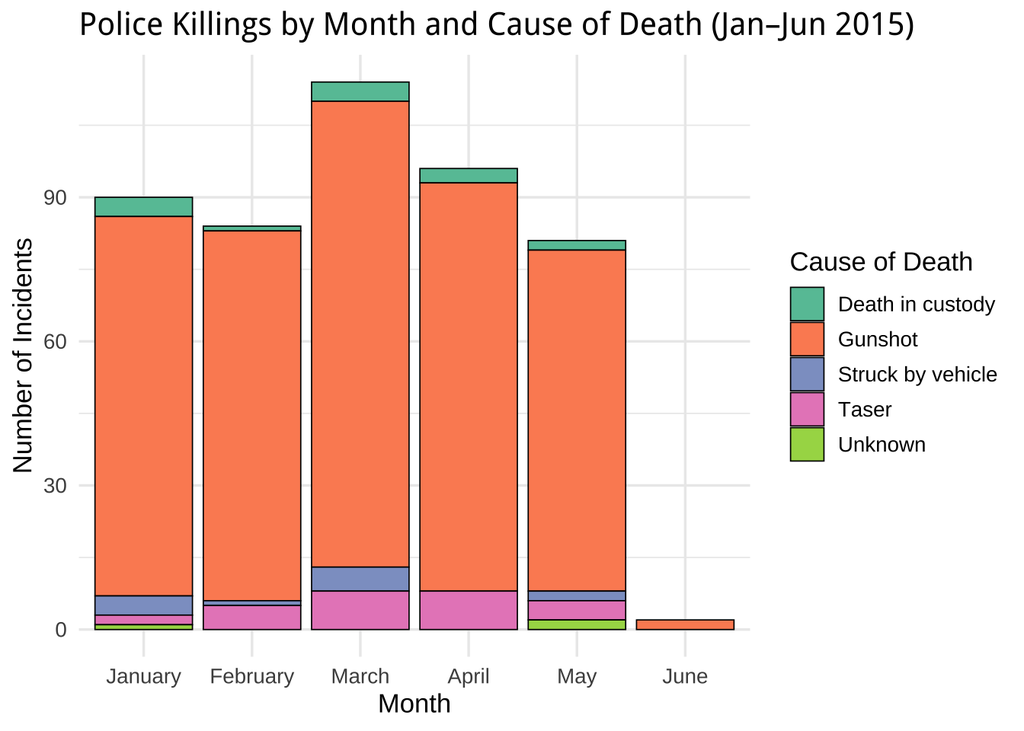

```r
ggplot(pk_raw, aes(x = month, fill = cause)) + geom_bar(color = "black", linewidth = 0.3) +
  labs(
    title = "Police Killings by Month and Cause of Death (Jan–Jun 2015)",
    x = "Month",
    y = "Number of Incidents",
    fill = "Cause of Death"
  ) +
  scale_fill_brewer(palette = "Set2") +
  theme_minimal(base_size = 13) +
  theme(
    plot.title = element_text(face = "bold"),
    legend.position = "right"
  )
```

### Q2: Do certain law enforcement agencies appear more frequently in incidents occurring in low-income tracts?

“comp_income” (the ratio of tract household income to county household income) is used to classify each census tract. Low (comp_income < 0.75), Medium (0.75–1.00), and High (> 1.00). Agencies with at least 3 incidents are recorded. Several agencies show a disproportionate share of incidents in low-income tracts. Oklahoma City Police Department stands out: 4 of its 5 incidents (80%) occurred in tracts where household income was less than 75% of the county average, with a mean of “comp_income” only 0.74. Phoenix Police Department follows at 75% low-income (mean 0.56). These percentages are well above the dataset-wide baseline of 35.1%. On the other end, agencies like the Austin Police Department, New Jersey State Police, San Francisco Police Department, and US Border Patrol have zero incidents in low-income tracts. This suggests that the economic context of policing incidents varies extremely differently by agency, even within the same state (e.g., LAPD at 40% low-income vs. SFPD at 0%). However, agencies with few incidents (3–5) are subject to high variance, so these patterns should be interpreted carefully.

```r
df <- df %>%
  mutate(income_level = case_when(
    comp_income < 0.75 ~ "Low",
    comp_income <= 1.00 ~ "Medium",
    comp_income > 1.00 ~ "High",
    TRUE ~ NA_character_
  ))

agency_counts <- df %>%
  count(lawenforcementagency, name = "total_incidents") %>%
  filter(total_incidents >= 3)

q2_table <- df %>%
  filter(lawenforcementagency %in% agency_counts$lawenforcementagency) %>%
  group_by(lawenforcementagency) %>%
  summarise(
    State          = first(state),
    Total          = n(),
    Low_Income_N   = sum(income_level == "Low", na.rm = TRUE),
    Pct_Low_Income = round(100 * Low_Income_N / Total, 1),
    Mean_Comp_Inc  = round(mean(comp_income, na.rm = TRUE), 3),
    .groups = "drop"
  ) %>%
  arrange(desc(Pct_Low_Income))

kable(q2_table,
      col.names = c("Agency", "State", "Total Incidents", "Low-Income Tracts (N)", "% Low-Income", "Mean comp_income"),
      caption = "Table: Agency-Level Breakdown by Census Tract Income Level (Agencies with 3+ Incidents)")
```

Table: Agency-Level Breakdown by Census Tract Income Level (Agencies with 3+ Incidents)

| Agency | State | Total Incidents | Low-Income Tracts (N) | % Low-Income | Mean comp_income |
| --- | --- | --- | --- | --- | --- |
| Oklahoma City Police Department | OK | 5 | 4 | 80.0 | 0.740 |
| Phoenix Police Department | AZ | 4 | 3 | 75.0 | 0.564 |
| Omaha Police Department | NE | 3 | 2 | 66.7 | 0.863 |
| Riverside County Sheriff’s Department | CA | 3 | 2 | 66.7 | 0.649 |
| Los Angeles County Sheriff’s Department | CA | 5 | 3 | 60.0 | 0.901 |
| Fort Worth Police Department | TX | 4 | 2 | 50.0 | 1.023 |
| New York Police Department | NY | 4 | 2 | 50.0 | 0.836 |
| Los Angeles Police Department | CA | 10 | 4 | 40.0 | 0.844 |
| El Paso Police Department | TX | 3 | 1 | 33.3 | 0.891 |
| Jefferson Parish Sheriff’s Office | LA | 3 | 1 | 33.3 | 0.705 |
| Pennsylvania State Police | PA | 3 | 1 | 33.3 | 0.845 |
| San Antonio Police Department | TX | 3 | 1 | 33.3 | 1.008 |
| Indianapolis Metropolitan Police Department | IN | 4 | 1 | 25.0 | 0.854 |
| US Marshals Service | TX | 5 | 1 | 20.0 | 0.817 |
| Austin Police Department | TX | 3 | 0 | 0.0 | 1.214 |
| New Jersey State Police | NJ | 3 | 0 | 0.0 | 1.042 |
| San Francisco Police Department | CA | 3 | 0 | 0.0 | 1.050 |
| US Border Patrol | WA | 3 | 0 | 0.0 | 1.041 |

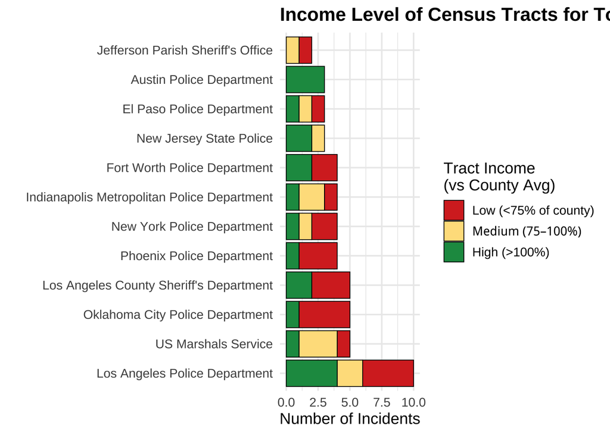

```r
top12 <- df %>%
  count(lawenforcementagency, sort = TRUE) %>%
  slice_head(n = 12) %>%
  pull(lawenforcementagency)

df %>%
  filter(lawenforcementagency %in% top12, !is.na(income_level)) %>%
  mutate(
    income_level = factor(income_level, levels = c("Low","Medium","High")),
    lawenforcementagency = factor(lawenforcementagency,
                                  levels = rev(names(sort(table(lawenforcementagency)))))
  ) %>%
  ggplot(aes(y = lawenforcementagency, fill = income_level)) +
  geom_bar(color = "black", linewidth = 0.3) +
  scale_fill_manual(
    values = c("Low" = "#d73027", "Medium" = "#fee08b", "High" = "#1a9850"),
    labels = c("Low (<75% of county)", "Medium (75–100%)", "High (>100%)")
  ) +
  labs(
    title = "Income Level of Census Tracts for Top 12 Law Enforcement Agencies",
    x = "Number of Incidents",
    y = "",
    fill = "Tract Income\n(vs County Avg)"
  ) +
  theme_minimal(base_size = 13) +
  theme(plot.title = element_text(face = "bold"))
```

# Orator: Sunita Singh

### Q1: How does the poverty(pov) rate correlate to police killings?

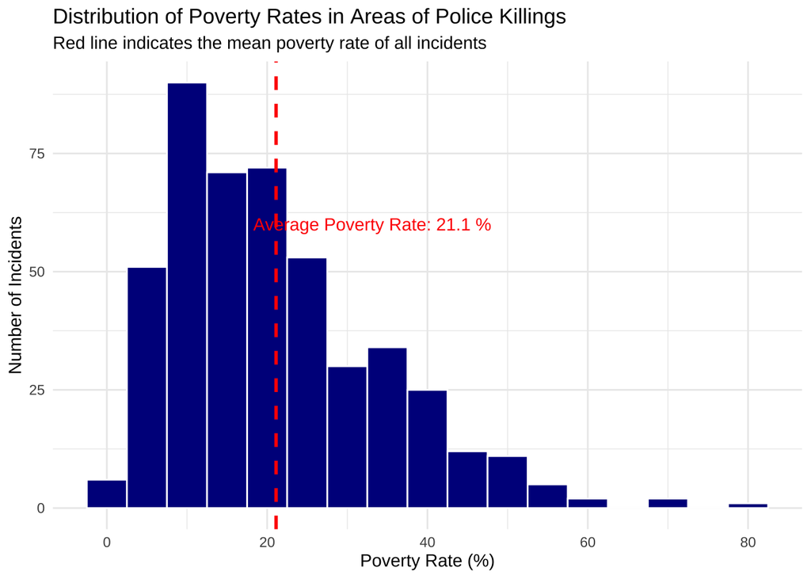

```r
df_clean <- df %>% filter(!is.na(pov))

ggplot(df_clean, aes(x = pov)) +
  geom_histogram(binwidth = 5, fill = "darkblue", color = "white") +
  geom_vline(aes(xintercept = mean(pov)), color = "red", linetype = "dashed", size = 1) +
  annotate("text", x = mean(df_clean$pov) + 12, y = 60,
           label = paste("Average Poverty Rate:", round(mean(df_clean$pov), 1), "%"), color = "red") +
  labs(title = "Distribution of Poverty Rates in Areas of Police Killings",
       subtitle = "Red line indicates the mean poverty rate of all incidents",
       x = "Poverty Rate (%)",
       y = "Number of Incidents") +
  theme_minimal()
```

### Q2: How does the employment rate(urate) relate to the rate of police killings?

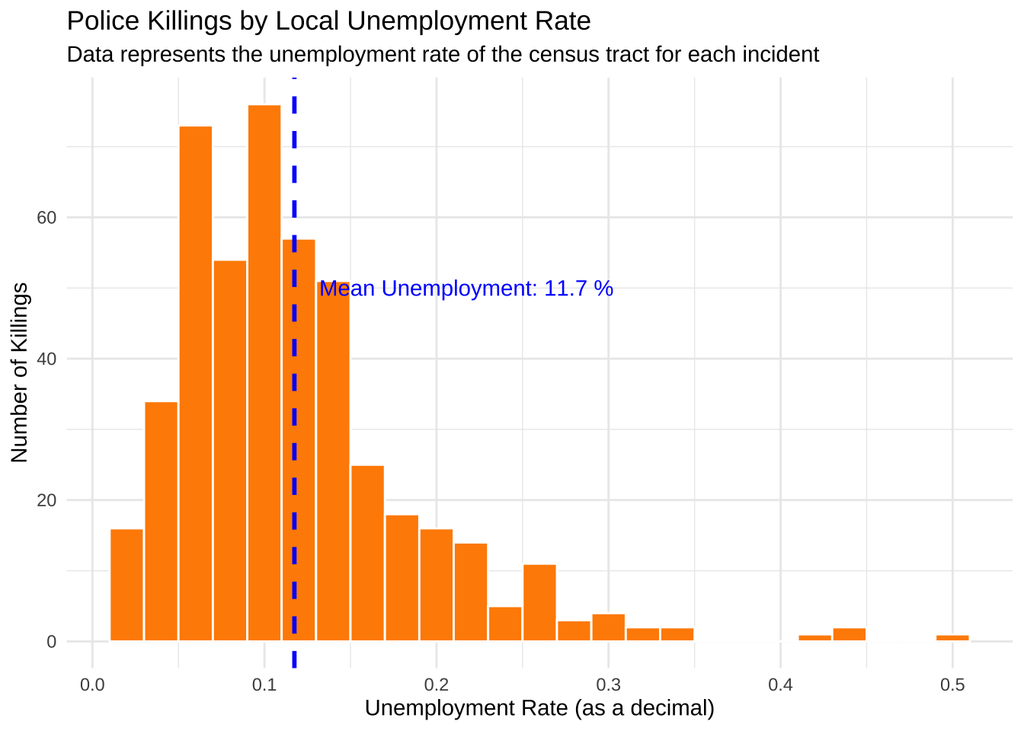

```r
df_clean <- df %>% filter(!is.na(urate))

ggplot(df_clean, aes(x = urate)) +
  geom_histogram(binwidth = 0.02, fill = "darkorange", color = "white") +
  geom_vline(aes(xintercept = mean(urate)), color = "blue", linetype = "dashed", size = 1) +
  annotate("text", x = mean(df_clean$urate) + 0.1, y = 50,
           label = paste("Mean Unemployment:", round(mean(df_clean$urate) * 100, 1), "%"), color = "blue") +
  labs(title = "Police Killings by Local Unemployment Rate",
       subtitle = "Data represents the unemployment rate of the census tract for each incident",
       x = "Unemployment Rate (as a decimal)",
       y = "Number of Killings") +
  theme_minimal()
```

If the “Mean Unemployment” (the blue dashed line) is significantly higher than the national average at the time (which was roughly 5.3% in 2015), it indicates that police killings are not randomly distributed. They are clustered in neighborhoods facing higher economic hardship. The histogram helps demonstrate whether police-involved shootings are a phenomenon tied to the economic health of a community. If the bars are tallest in the 10%–20% unemployment range, it highlights that the “rate of police killings” is linked to the socio-economic status of the location.

# Deliverer: Michael Bernier

### Q1: Are the victims of police killings more likely to be in tracts with a lower income than the general county?

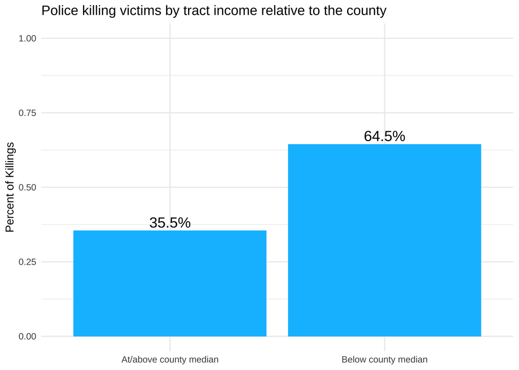

```r
dfq1 <- df %>%
  filter(!is.na(comp_income),
         comp_income > 0) |>
  mutate(income_group = if_else(comp_income < 1,"Below county median", "At/above county median")) |>
  count(income_group) |>
  mutate(percent = n / sum(n))
  ggplot(dfq1, aes(x = income_group, y = percent)) +
  geom_col(fill = "deepskyblue1") +
  geom_text(aes(label = scales::percent(percent, accuracy = 0.1)), vjust = -0.3, size = 5) +
  labs(
    title = "Police killing victims by tract income relative to the county",
    x = NULL,
    y = "Percent of Killings"
  ) +
  ylim(0, 1) +
  theme_minimal()
```

```r
dfq1
```

```
##             income_group   n   percent
## 1 At/above county median 165 0.3548387
## 2    Below county median 300 0.6451613
```

This figure analyzes the amount of police victims whose household income is either equal to or above the county median household income or lower than the county median household income. It is evident from the graph, that the majority of killings involved victims whose household income was lower than their county’s median income. This suggests that people from relatively lower-income neighborhoods (when compared to the rest of the county) are disproportionately represented among victims.

### Q2: Can we predict whether a victim was armed based on socioeconomic factors?

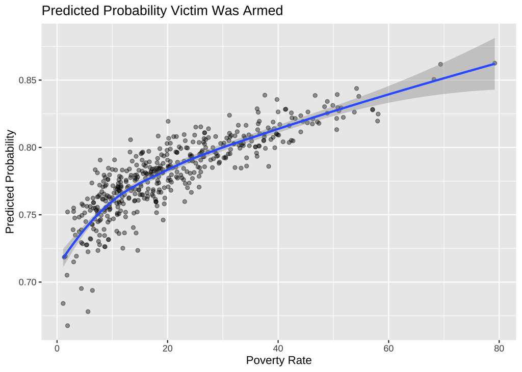

```r
armedpredict <- df[, c("armed", "college", "urate", "h_income", "pov")]
armedpredict <- na.omit(armedpredict)
armedpredict <- armedpredict |>
  mutate(
    armed_yn = ifelse(armed == "No", 0, 1)
  )
armedmodel <- glm(armed_yn ~ college + urate + h_income + pov,
             data = armedpredict,
             family = binomial)
armedpredict$predicted <- predict(armedmodel, type = "response")

ggplot(armedpredict, aes(x = pov, y = predicted)) +
  geom_point(alpha = 0.4) +
  geom_smooth() +
  labs(
    title = "Predicted Probability Victim Was Armed",
    x = "Poverty Rate",
    y = "Predicted Probability"
  )
```

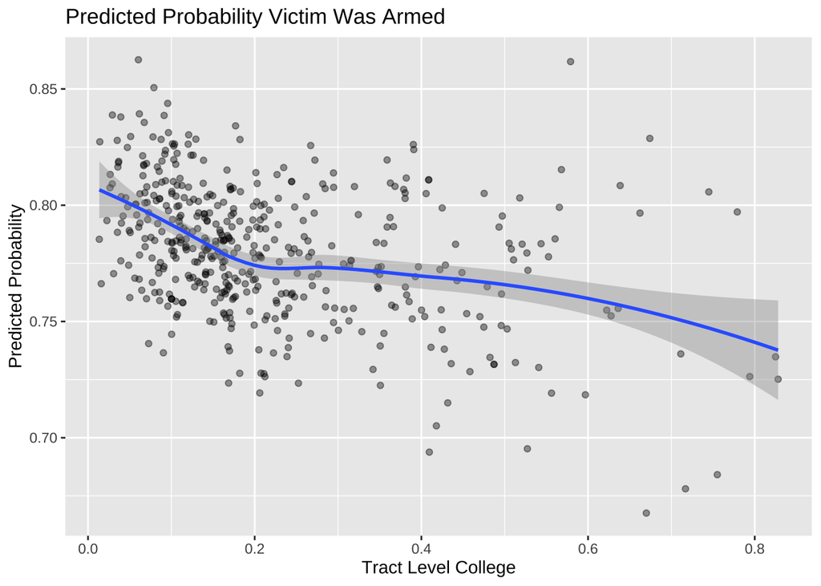

```r
ggplot(armedpredict, aes(x = college, y = predicted)) +
  geom_point(alpha = 0.4) +
  geom_smooth() +
  labs(
    title = "Predicted Probability Victim Was Armed",
    x = "Tract Level College",
    y = "Predicted Probability"
  )
```

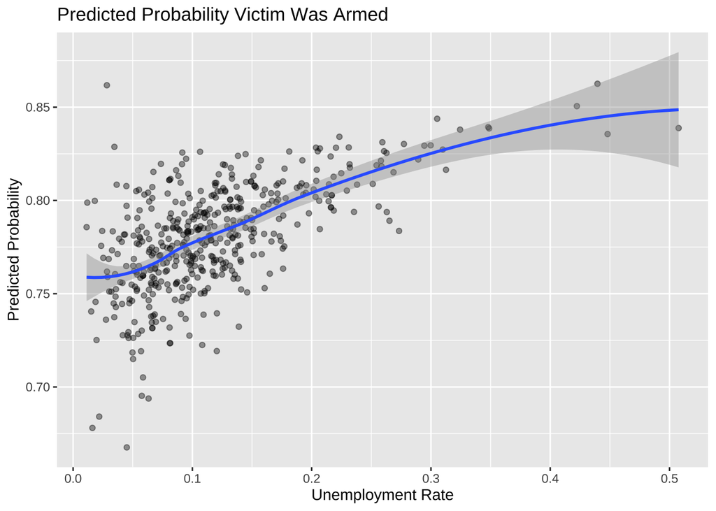

```r
ggplot(armedpredict, aes(x = urate, y = predicted)) +
  geom_point(alpha = 0.4) +
  geom_smooth() +
  labs(
    title = "Predicted Probability Victim Was Armed",
    x = "Unemployment Rate",
    y = "Predicted Probability"
  )
```

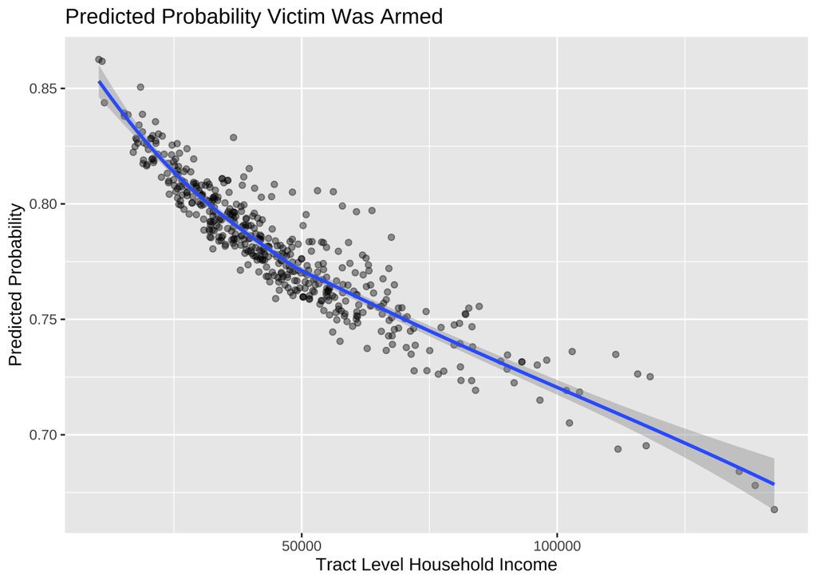

```r
ggplot(armedpredict, aes(x = h_income, y = predicted)) +
  geom_point(alpha = 0.4) +
  geom_smooth() +
  labs(
    title = "Predicted Probability Victim Was Armed",
    x = "Tract Level Household Income",
    y = "Predicted Probability"
  )
```

These four graphs depict the model’s prediction of whether a victim was armed based on the victims household income and neighborhood characteristics including the poverty rate, unemployment rate and college education rate. The model predictions increase in areas with more poverty and unemployment and but they also decrease in areas with a education and where the victim’s household income is higher.

# Additional Questions

### Q1: What percentage of armed victims were killed by gunshot? How does this percentage compare to those who were unarmed?

```r
df |>
  count(cause, armed) |>
  group_by(cause) |>
  mutate(percent = n / sum(n)) |>
  ungroup() |>
  select(cause, armed, percent) |>
  pivot_wider(
    names_from = armed,
    values_from = percent,
    values_fill = 0
  ) |>
  gt() |>
  cols_label(
    cause = "Cause",
    No = "Unarmed",
    Yes = "Armed"
  ) |>
  fmt_percent(columns = c(No, Yes), decimals = 1) |>
  tab_header(
    title = "Police killings by cause and armed status",
    subtitle = "Percent within each cause"
  )
```

Police killings by cause and armed status

Percent within each cause

| Cause | Unarmed | Armed |
| --- | --- | --- |
| Gunshot | 22.1% | 77.9% |
| Other | 19.6% | 80.4% |

### Q2: How do police killings vary across different ages? (age groups - 0-18, 19-29, 30-39, 40-49, 50-59, 60+)

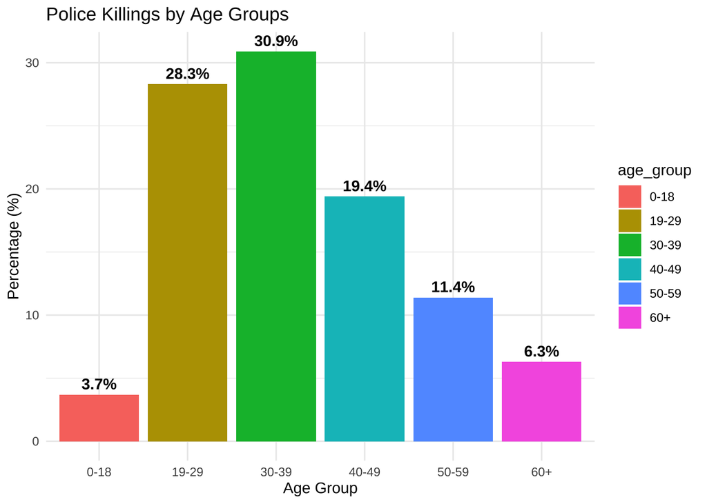

```r
suppressWarnings(df_clean <- df %>%
  mutate(age = as.numeric(age)) %>%
  filter(!is.na(age)))
df_clean <- df_clean %>%
  mutate(age_group = case_when(
    age <= 18 ~ "0-18",
    age >= 19 & age <= 29 ~ "19-29",
    age >= 30 & age <= 39 ~ "30-39",
    age >= 40 & age <= 49 ~ "40-49",
    age >= 50 & age <= 59 ~ "50-59",
    age >= 60 ~ "60+",
    TRUE ~ "Unknown"
  ))

summary_table <- df_clean %>%
  count(age_group) %>%
  mutate(percentage = round((n / sum(n)) * 100, 1))
ggplot(summary_table, aes(x = age_group, y = percentage, fill = age_group)) +

  geom_bar(stat = "identity", show.legend = TRUE) +

  geom_text(aes(label = paste0(percentage, "%")),
            vjust = -0.5,
            fontface = "bold") +

  labs(title = "Police Killings by Age Groups",
       x = "Age Group",
       y = "Percentage (%)") +

  theme_minimal()
```

```r
print(summary_table)
```

```
##   age_group   n percentage
## 1      0-18  17        3.7
## 2     19-29 131       28.3
## 3     30-39 143       30.9
## 4     40-49  90       19.4
## 5     50-59  53       11.4
## 6       60+  29        6.3
```

# Follow-up Questions

### New Questions Based Off Initial Investigation

- Q1: Does the victim’s age differ significantly across racial groups? Is there an age gap after controlling for the tract’s poverty, unemployment and income?
- Q2: Do certain socioeconomic factors amplify the effect of low income on police killings? In other words, is low income alone insufficient, but becomes more impactful when combined with factors such as high poverty, high unemployment, or low education?
- Q3: Are victims in the lowest income quintile tracts significantly different (in race, age, armed status) compared to those in the highest quartile?
- Q4: How do different racial groups differ in the proportion of victims whose race matches the dominant racial group of the tract?

### Investigation of Follow-up Questions

Our group decided to investigate question 1 and question 4 in further detail.

Follow Up Question 1:

```r
df$age_num <- suppressWarnings(as.numeric(df$age))
df$pov <- suppressWarnings(as.numeric(df$pov))

pk_age <- df %>%
  filter(raceethnicity %in% c("White", "Black", "Hispanic/Latino"),
         !is.na(age_num), !is.na(pov))

#poverty tertiles
pov_cuts <- quantile(pk_age$pov, probs = c(1/3, 2/3), na.rm = TRUE)

pk_age <- pk_age %>%
  mutate(pov_group = case_when(
    pov <= pov_cuts[1] ~ "Low Poverty",
    pov <= pov_cuts[2] ~ "Medium Poverty",
    pov > pov_cuts[2]  ~ "High Poverty"
  ),
  pov_group = factor(pov_group, levels = c("Low Poverty", "Medium Poverty", "High Poverty")))

age_summary <- pk_age %>%
  group_by(raceethnicity, pov_group) %>%
  summarise(n = n(),
            Mean_Age = round(mean(age_num), 1),
            Median_Age = median(age_num),
            .groups = "drop")

kable(age_summary,
      caption = "Victim Age by Race and Tract Poverty Level")
```

Victim Age by Race and Tract Poverty Level

| raceethnicity | pov_group | n | Mean_Age | Median_Age |
| --- | --- | --- | --- | --- |
| Black | Low Poverty | 38 | 34.5 | 34 |
| Black | Medium Poverty | 30 | 33.1 | 32 |
| Black | High Poverty | 65 | 33.6 | 30 |
| Hispanic/Latino | Low Poverty | 15 | 29.5 | 31 |
| Hispanic/Latino | Medium Poverty | 22 | 33.1 | 31 |
| Hispanic/Latino | High Poverty | 29 | 31.5 | 29 |
| White | Low Poverty | 92 | 41.9 | 39 |
| White | Medium Poverty | 93 | 39.8 | 36 |
| White | High Poverty | 50 | 39.1 | 40 |

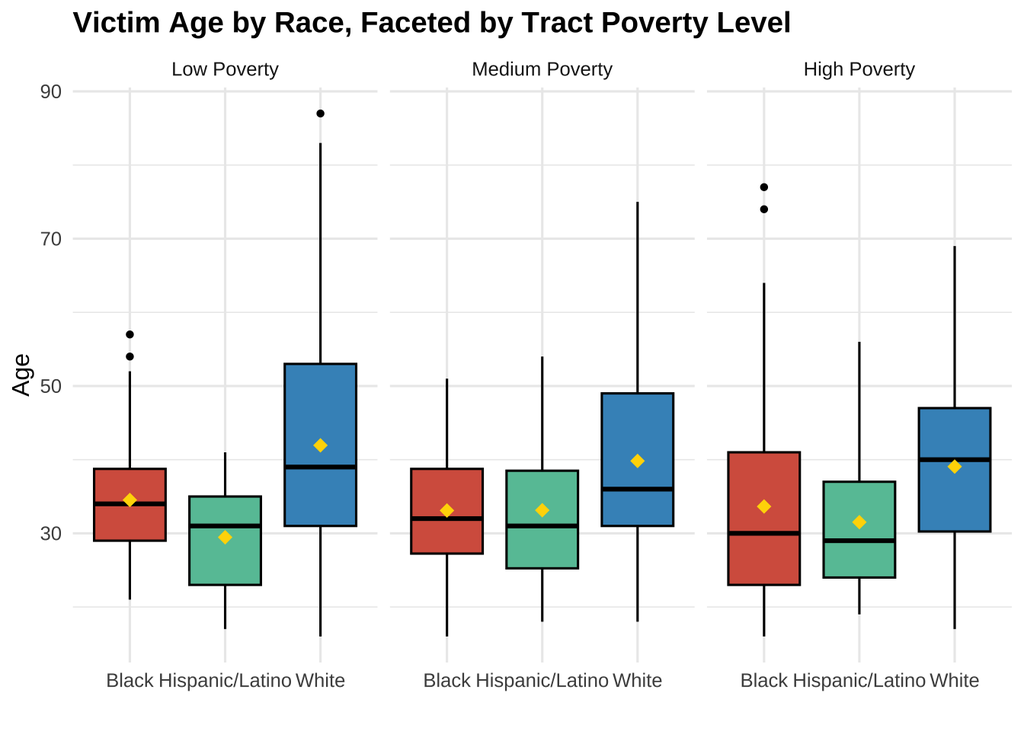

```r
ggplot(pk_age, aes(x = raceethnicity, y = age_num, fill = raceethnicity)) +
  geom_boxplot(color = "black", outlier.shape = 16, outlier.size = 1.5) +
  stat_summary(fun = mean, geom = "point", shape = 18, size = 3, color = "gold") +
  facet_wrap(~ pov_group) +
  scale_fill_manual(values = c("Black" = "#d6604d", "Hispanic/Latino" = "#66c2a5", "White" = "#4393c3")) +
  labs(
    title = "Victim Age by Race, Faceted by Tract Poverty Level",
    x = "", y = "Age"
  ) +
  theme_minimal(base_size = 12) +
  theme(plot.title = element_text(face = "bold"), legend.position = "none")
```

Follow Up Question 4:

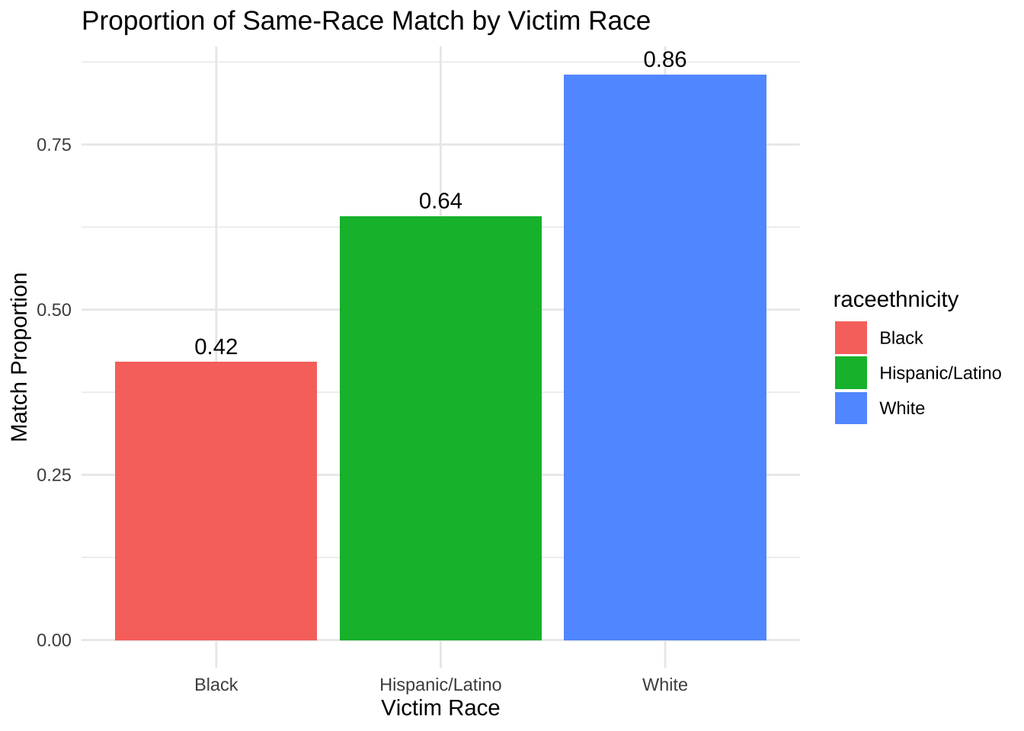

```r
plot_data <- df_q2 %>%
  mutate(match = ifelse(raceethnicity == dominant_race, 1, 0)) %>%
  group_by(raceethnicity) %>%
  summarise(match_proportion = mean(match, na.rm = TRUE))
ggplot(plot_data, aes(x = raceethnicity, y = match_proportion, fill = raceethnicity)) +
  geom_col() +
  geom_text(aes(label = round(match_proportion, 2)), vjust = -0.5) +
  labs(
    title = "Proportion of Same-Race Match by Victim Race",
    x = "Victim Race",
    y = "Match Proportion"
  ) +
  theme_minimal()
```

# Summary

In our initial investigation, we noticed that the police incidents were very concentrated among young and middle-aged adults. We also concluded that 60% of all the victims fall between the ages of 19 and 39, with a peak in age for those who are 30-39. We were a bit shocked at this because we were expecting a cluster of those in the late teens or twenties, since their frontal lobes are not yet fully developed and therefore might have judgment impairments. We also found that victims were more likely to be in tracts with a lower income than the county median income. Additionally, there was also a negative correlation between education levels and unemployment rates, which informed us that many of these incidents are clustered in areas with poor educational and economic resources. We also noticed how the average poverty rate in tracts with incidents is much higher than the national average poverty rate. An intriguing aspect that we noticed was the “racial match.” For white and Hispanic/Latino communities, they are most often killed in areas where they are the majority race. However, for Blacks, they are killed in predominantly white areas just as often as in predominantly black areas. With these descriptive visuals in mind, we were driven to create complex follow-up questions.

In our investigation of follow-up questions 1 and 4, we learned that the likelihood of a police incident isn’t just tied to the economics of the neighborhood, but also the geographic demographics. These questions are interesting because they allow us to see if factors like age and location “match” are consistent across different socioeconomic environments or if they are unique to specific racial groups. In order to investigate Q1, we created a boxplot in order to compare the victim ages across race and poverty levels. We found that Black and Hispanic victims are consistently younger than White victims, even when controlling for tract poverty. For Q4, we used a bar chart to calculate the proportion of “same-race matches” between victims and their tracts. This figure revealed that White victims are much more likely to be killed in tracts where their race is dominant, whereas victims of color often show different matching patterns, suggesting varying levels of demographic isolation during these incidents.